# Foundations for statistical inference - Confidence intervals

## Sampling from Ames, Iowa

If you have access to data on an entire population, say the size of every house in Ames, Iowa, it’s straight forward to answer questions like, “How big is the typical house in Ames?” and “How much variation is there in sizes of houses?”. If you have access to only a sample of the population, as is often the case, the task becomes more complicated. What is your best guess for the typical size if you only know the sizes of several dozen houses? This sort of situation requires that you use your sample to make inference on what your population looks like.

## The data

```r
library(mosaic)
library(oilabs)
library(ggformula)
```

In the previous lab, “Sampling Distributions”, we looked at the population data of houses from Ames, Iowa. Let’s start by loading that data set:

```r
data(ames)
glimpse(ames)
```

```
## Observations: 2,930
## Variables: 82
## $ Order           <int> 1, 2, 3, 4, 5, 6, 7, 8, 9, 10, 11, 12, 13, 14,...
## $ PID             <int> 526301100, 526350040, 526351010, 526353030, 52...
## $ area            <int> 1656, 896, 1329, 2110, 1629, 1604, 1338, 1280,...
## $ price           <int> 215000, 105000, 172000, 244000, 189900, 195500...
## $ MS.SubClass     <int> 20, 20, 20, 20, 60, 60, 120, 120, 120, 60, 60,...
## $ MS.Zoning       <fct> RL, RH, RL, RL, RL, RL, RL, RL, RL, RL, RL, RL...
## $ Lot.Frontage    <int> 141, 80, 81, 93, 74, 78, 41, 43, 39, 60, 75, N...
## $ Lot.Area        <int> 31770, 11622, 14267, 11160, 13830, 9978, 4920,...
## $ Street          <fct> Pave, Pave, Pave, Pave, Pave, Pave, Pave, Pave...
## $ Alley           <fct> NA, NA, NA, NA, NA, NA, NA, NA, NA, NA, NA, NA...
## $ Lot.Shape       <fct> IR1, Reg, IR1, Reg, IR1, IR1, Reg, IR1, IR1, R...
## $ Land.Contour    <fct> Lvl, Lvl, Lvl, Lvl, Lvl, Lvl, Lvl, HLS, Lvl, L...
## $ Utilities       <fct> AllPub, AllPub, AllPub, AllPub, AllPub, AllPub...
```

[output cut: 69 more lines]

Note that the data set has information on many housing variables, but for the first portion of the lab we’ll focus on the size of the house, represented by the variable `area`.

In this lab we’ll start with a simple random sample of size 60 from the population. Let’s create this sample with the following code:

```r
sample60 <- sample(ames, 60)
```

1. Describe the distribution of your sample. What would you say is the “typical” size within your sample? Also state precisely what you interpreted “typical” to mean.
2. Would you expect another student’s distribution to be identical to yours? Would you expect it to be similar? Why or why not?

## Confidence intervals

One of the most common ways to describe the typical or central value of a distribution is to use the mean. In this case we can calculate the mean of the sample using,

```r
sample_mean <- mean(~ area, data = sample60)
```

Return for a moment to the question that first motivated this lab: based on this sample, what can we infer about the population? Based only on this single sample, the best estimate of the average living area of houses sold in Ames would be the sample mean, usually denoted as $\bar{x}$ (here we’re calling it `sample_mean`). That serves as a good *point estimate* but it would be useful to also communicate how uncertain we are of that estimate. This can be captured by using a *confidence interval*.

We can calculate a 95% confidence interval for a sample mean by adding and subtracting a particular number of standard errors. You might have that number memorized for the 95% confidence interval, but lets use `qnorm()` to confirm.

```r
zstar <- qnorm(0.975) # why 0.975?
zstar
```

```
## [1] 1.959964
```

zstar is actually the 97.5th percentile of the standard normal distribution.

Now we can build the confidence interval:

```r
se <- sd(~ area, data = sample60) / sqrt(60)

lower <- sample_mean - zstar * se

upper <- sample_mean + zstar * se

c(lower, upper)
```

```
## [1] 1271.626 1569.040
```

This is an important inference that we’ve just made: even though we don’t know what the full population looks like, we’re 95% confident that the true average size of houses in Ames lies between the values *lower* and *upper*. There are a few conditions that must be met for this interval to be valid.

3. For the confidence interval to be valid, the sample mean must be normally distributed and have standard error $s / \sqrt{n}$. What conditions must be met for this to be true?

## Confidence levels

4. What does “95% confidence” mean? If you’re not sure, see Section 2.8.4.

In this case we have the luxury of knowing the true population mean since we have data on the entire population. This value can be calculated using the following command:

```r
mean(~ area, data = ames)
```

```
## [1] 1499.69
```

5. Does your confidence interval capture the true average size of houses in Ames? If you are working on this lab in a classroom, does your neighbor’s interval capture this value?
6. Each student in your class should have gotten a slightly different confidence interval. What proportion of those intervals would you expect to capture the true population mean? Why? If you are working in this lab in a classroom, collect data on the intervals created by other students in the class and calculate the proportion of intervals that capture the true population mean.

Using R, we’re going to recreate many samples to learn more about how sample means and confidence intervals vary from one sample to another. The *do()* function comes in handy here (If you are unfamiliar with `do()`, review the [Sampling Distribution Lab](http://htmlpreview.github.io/?https://github.com/beanumber/oiLabs-mosaic/blob/master/sampling_distributions/sampling_distributions.html)).

Here is the rough outline:

- Obtain a random sample.
- Calculate and store the sample’s mean and standard deviation.
- Repeat steps (1) and (2) 50 times.
- Use these stored statistics to calculate many confidence intervals.

We can accomplish this using the `do()` and `favstats()` functions in the `mosaic` package. The following lines of code take a uniform random `sample()` of size 60 from `population`, computes several summary statistics (including `mean` and `sd`), and then does this 50 times and saves the result as a data frame.

```r
n <- 60
samp_ci <- do(50) * favstats(~ area, data = sample(ames, size = n))
```

Lastly, we construct the confidence intervals.

```r
samp_ci <- samp_ci %>%
  mutate(se = sd / sqrt(n)) %>%
  mutate(lower = mean - zstar * se) %>%
  mutate(upper = mean + zstar * se)
```

Lower bounds of these 50 confidence intervals are stored in `lower`, and the upper bounds are in `upper`. Let’s view the first interval.

```r
samp_ci %>%
  select(upper, lower) %>%
  slice(1)
```

```
##     upper    lower
## 1 1640.12 1388.046
```

The `slice()` function selects rows by position.

Now, we can plot how many of our confidence intervals intersect the true population mean using the `plot_ci` function.

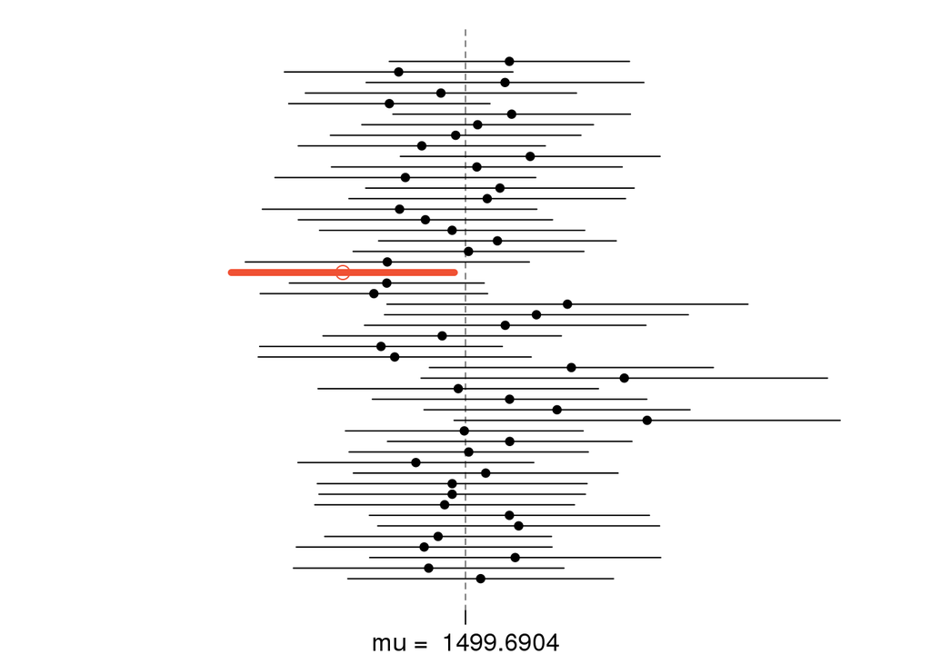

```r
with(samp_ci, plot_ci(lower, upper, m = mean(~ area, data = ames)))
```

```r
# In addition, mosaic::CISim() has similar functionalities
```

7. How many of your confidence intervals contained the true mean? Is this the number you expected to see?

## On your own

So far, we have only focused on estimating the mean living area in homes in Ames. Now you’ll try to estimate the mean home price.

- Create 50 random samples of size 60. Generate 95% confidence intervals for each of your samples, and plot the confidence intervals with the `plot_ci` function. What proportion of your confidence intervals include the true population mean of `home price`? Is this proportion exactly equal to the confidence level? If not, explain why.

```r
with(samp_ci, plot_ci(lower, upper, m = mean(~ area, data = ames)))
```

[output not shown]

- Pick a confidence level of your choosing, provided it is not 95% or 99%. What is the appropriate critical value?
- Calculate 50 confidence intervals at the confidence level you chose in the previous question. You do not need to obtain new samples, simply calculate new intervals based on the sample means and standard deviations you have already collected. Using the *plot_ci* function, plot all intervals and calculate the proportion of intervals that include the true population mean of `home price`. How does this percentage compare to the confidence level selected for the intervals?

This is a product of OpenIntro that is released under a [Creative Commons Attribution-ShareAlike 3.0 Unported](http://creativecommons.org/licenses/by-sa/3.0). This lab was written for OpenIntro by Andrew Bray and Mine Çetinkaya-Rundel. These materials were adapted to functions in the `mosaic` and `ggformula` packages by Nicholas Horton and Bonnie Lin (Amherst College).